# Mechanistic model

Piotr Szefer

1/18/2023

To investigate further what are the possible outcomes and mechanisms in our experiment we build a mechanistic RM model based on (McCann). The model we use is as follows:

$$\begin{matrix} \frac{dP}{dt} = rP \left( 1-\frac{P}{K} \right)-\frac{\Omega_{HP}x_{H}y_{H}PH}{P+P_0} \\
\frac{dH}{dt} = -x_HH\left(1-\frac{\Omega_{HP}y_HP}{P+P0}\right)-\frac{\Omega_{SH}x_{S}y_SHS}{H+H_0}-\frac{\Omega_{BH}y_Bx_BHB}{o_{BH}H+(1-\Omega_{BH})S+H_0} \\
dS = -x_SS \left( 1- \frac{\Omega_{SH}y_SH}{H+H_0}\right)- \frac{(1-\Omega_{BH})y_Bx_BSB}{\Omega_{BH}H+(1-\Omega_{BH})S+H_0} \\
dB = -x_BB \left( 1-\frac{\Omega_{BH}y_BH+(1-\Omega_{BH})y_BS}{\Omega_{BH}H+(1-\Omega_{BH})S+H_0)} \right) \end{matrix}$$

Parameters are: $\Omega_ij$ preference of a consumer $i$ to a resource $j$. $x_i$ - mass specific metabolic rate, $y_i$ - measure of ingestion rate. There is no indication of an attack rate, would that be the $x_i$? $y_i$ is limited by an animal’s physiological capacity.

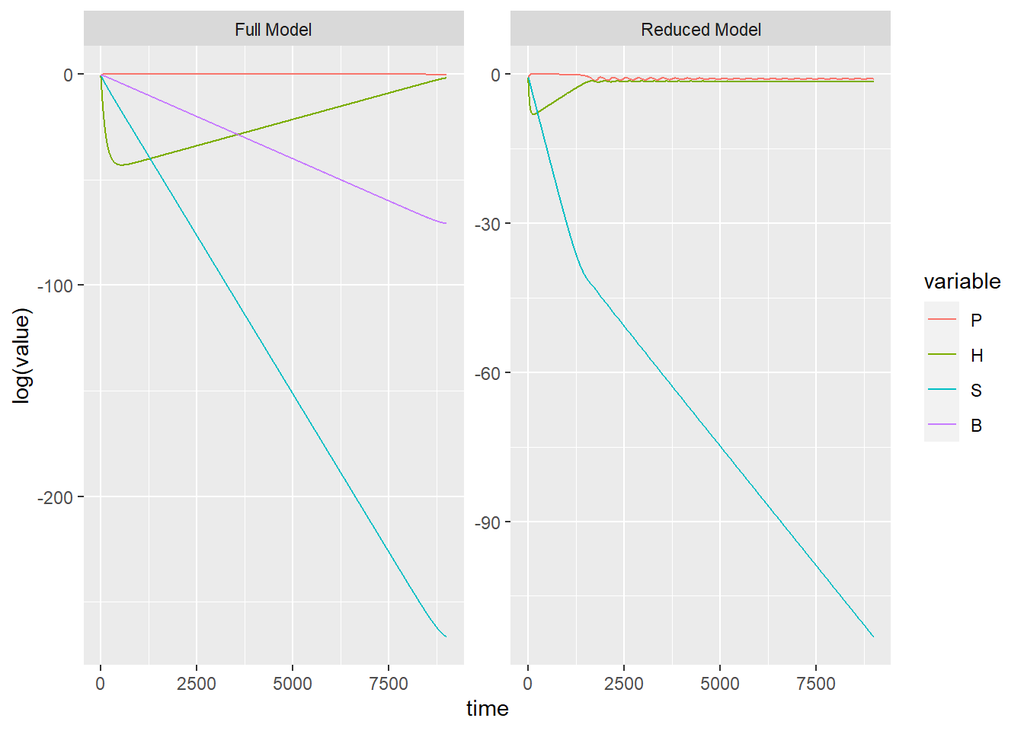

```r
library(deSolve)
# Define full model
# fullModule <- function(t, state, parameters) {
#   with(as.list(c(state, parameters)),{
#     dP <-  r*P*(1-P/K)-(o_HP*x_H*y_H*P*H)/(P+P0)
#     dH <- -x_H*H*(1-(o_HP*y_H*P)/(P+P0))-(o_SH*x_S*y_S*H*S)/(H+H0)-(o_BH*y_B*x_B*H*B)/(o_BH*H+(1-o_BH)*S+H0)
#     dS <- -x_S*S*(1-(o_SH*y_S*H)/(H+H0))-((1-o_BH)*y_B*x_B*S*B)/(o_BH*H+(1-o_BH)*S+H0)
#     dB <- -x_B*B*(1-(o_BH*y_B*H+(1-o_BH)*y_B*S)/(o_BH*H+(1-o_BH)*S+H0))
#     list(c(dP,dH,dS,dB))
#   })
# }
#
# reducedModule <- function(t, state, parameters) {
#   # This models the a simple food chain without the top predators
#   with(as.list(c(state, parameters)),{
#     dP <-  r*P*(1-P/K)-(o_HP*x_H*y_H*P*H)/(P+P0)
#     dH <- -x_H*H*(1-(o_HP*y_H*P)/(P+P0))-(o_SH*x_S*y_S*H*S)/(H+H0)
#     dS <- -x_S*S*(1-(o_SH*y_S*H)/(H+H0))
#     list(c(dP,dH,dS))
#   })
# }

# Remove metabolic rate from the biomass removal equation
fullModule <- function(t, state, parameters) {
  with(as.list(c(state, parameters)),{
    dP <-  r*P*(1-P/K)-(o_HP*y_H*P*H)/(P+P0)
    dH <- -x_H*H*(1-(o_HP*y_H*P)/(P+P0))-(o_SH*y_S*H*S)/(H+H0)-(o_BH*y_B*H*B)/(o_BH*H+(1-o_BH)*S+H0)
    dS <- -x_S*S*(1-(o_SH*y_S*H)/(H+H0))-((1-o_BH)*x_B*S*B)/(o_BH*H+(1-o_BH)*S+H0)
    dB <- -x_B*B*(1-(o_BH*y_B*H+(1-o_BH)*y_B*S)/(o_BH*H+(1-o_BH)*S+H0))
    list(c(dP,dH,dS,dB))
  })
}

reducedModule <- function(t, state, parameters) {
  # This models the a simple food chain without the top predators
  with(as.list(c(state, parameters)),{
    dP <-  r*P*(1-P/K)-(o_HP*y_H*P*H)/(P+P0)
    dH <- -x_H*H*(1-(o_HP*y_H*P)/(P+P0))-(o_SH*y_S*H*S)/(H+H0)
    dS <- -x_S*S*(1-(o_SH*y_S*H)/(H+H0))
    list(c(dP,dH,dS))
  })
}


# mass specific metabolic rate
metabolic_rate_herbivores <- 0.2
metabolic_rate_birds <- 0.08
metabolic_rate_spiders <- 0.3

# ingestion rate per unit metabolic rate of species i
multipl <- 1
ingestion_rate_herbivores <- 1.5 * multipl
ingestion_rate_birds <- 5 * multipl
ingestion_rate_spiders <- 2.1 * multipl

half_sat_plants <- 0.2
half_sat_herbivores <- 0.5

params_fm <- c(r = 1         ,
            K = 1       , # environmental


            o_BS = 0.6    , # preference of birds for spiders
            o_BH = 0.4    , # preference of birds for herbivores
            o_HP = 1      , # preference of herbivores for plants
            o_SH = 1      , # preference of spiders for herbivores


            x_H  = metabolic_rate_herbivores,
            x_B  = metabolic_rate_birds,
            x_S  = metabolic_rate_spiders,

            y_H  = ingestion_rate_herbivores  ,
            y_B  = ingestion_rate_birds  ,
            y_S  = ingestion_rate_spiders    , # ing.rates

            P0   = half_sat_plants,
            H0   = half_sat_herbivores)

params_rm <- c(r = 1         ,
               K = 1       , # environmental


               o_HP = 1      , # preference of herbivores for plants
               o_SH = 1      , # preference of spiders for herbivores


               x_H  = metabolic_rate_herbivores,
               x_S  = metabolic_rate_spiders,

               y_H  = ingestion_rate_herbivores  ,
               y_B  = ingestion_rate_birds  ,
               y_S  = ingestion_rate_spiders ,

               P0   = half_sat_plants,
               H0   = half_sat_herbivores)


stateFM <- c(P = 0.5, H = 0.5, S = 0.5, B = 0.5)
stateRM <- c(P = 0.5, H = 0.5, S = 0.5)
times <- seq(0,900, by = 0.1)

outFM <- ode(y = stateFM, times = times, func = fullModule,    parms = params_fm)
outRM <- ode(y = stateRM, times = times, func = reducedModule, parms = params_rm)

library(reshape2)
df.fm <- data.frame(time = 1:nrow(outFM), outFM[,-1])
df.fm.melt <- melt(df.fm, id = "time")
df.fm.melt$model <- "Full Model"

df.rm <- data.frame(time = 1:nrow(outRM), outRM[,-1])
df.rm.melt <- melt(df.rm, id = "time")
df.rm.melt$model <- "Reduced Model"

df.bm <- rbind(df.fm.melt, df.rm.melt)

library(ggplot2)
ggplot(df.bm, aes(x = time, y = log(value), color = variable))+
  geom_line()+
  facet_wrap(~model, scales = "free")
```

Now that we have a functioning model we can try to scan the parameter space of **interaction strength** as it was done in the mentioned paper.

The per-capita interaction strength of resource i on consumer k was defined as
$$\alpha_{k,i} = \frac{K_k(i)}{i} = \frac{\Omega_{ki}x_ky_k}{\Omega_{ki}i + (1 - \Omega_{ki})j + i_0}$$

The **interaction strength** was defined as the maximum per capita interaction strength of resource of resource species j on the consumer species i. Per capita interaction strength is maximum when densities of j and i approach zero. Therefore:
$$I_{ki} = \frac{\Omega_{ki}x_ky_k}{i_0}$$

But we will get to that later. Now a sample of what the algorithm can do.

First of all we need to focus mainly on an abstract relations between parameters. We are not interested how did parameters change but rather what phenomenons (like a change in interaction strength) can explain, at least qualitatively, the observed patterns in LRR.

Possible hypotheses. The advantage of the above model is a possibility of estimation of plausible values of the $x_k$ and $y_k$ parameters as well as working with interaction strengths. This allows us to form our hypothesis in terms of interaction strengths:

1. Spiders feed more on herbivores - interaction strength increases in the absence of predators? What I would need is a model where the capture rates are explicit. But I can maybe work with what I have here.

What are the parameters and what do I know about them.

```r
# I can manipulate three parameters, lets say
runModel <- function(r=1,K=1, o_BS=0.7, o_BH=0.3, o_HP=1, o_SH=1, x_H=0.01, x_B=0.0008,
                     x_S=0.02, y_H=2.009, y_B=4, y_S=3.5, P0=0.16129,H0=0.9, rr = 1, rK = 1,
                     ro_HP = 1, ro_SH = 1, rx_H=0.01, rx_S=0.02, ry_H  = 2.009, ry_S  = 3.5,
                     rP0=0.16129,rH0=0.9,
                     stateFM = c(P = 0.5, H = 0.5, S = 0.5, B = 0.5),
                     stateRM = c(P = 0.5, H = 0.5, S = 0.5),
                     times = seq(0,900, by = 0.1)) {
  params_fm <- c(r=r,
                 K=K,
                 o_BS = o_BS,
                 o_BH = o_BH,
                 o_HP = o_HP,
                 o_SH = o_SH,
                 x_H  = x_H,
                 x_B  = x_B,
                 x_S  = x_S,
                 y_H  = y_H,
                 y_B  = y_B,
                 y_S  = y_S,
                 P0   = P0,
                 H0   = H0)
  params_rm <- c(r    = rr,
                 K    = rK,
                 o_HP = ro_HP,
                 o_SH = ro_SH,
                 x_H  = rx_H,
                 x_S  = rx_S,
                 y_H  = ry_H,
                 y_S  = ry_S,
                 P0   = rP0,
                 H0   = rH0)
# Itegrate
outFM <- ode(y = stateFM, times = times, func = fullModule,    parms = params_fm)
outRM <- ode(y = stateRM, times = times, func = reducedModule, parms = params_rm)
df.fm <- data.frame(time = 1:nrow(outFM), outFM[,-1])
df.fm.melt <- melt(df.fm, id = "time")
df.fm.melt$model <- "Full Model"
df.rm <- data.frame(time = 1:nrow(outRM), outRM[,-1])
df.rm.melt <- melt(df.rm, id = "time")
df.rm.melt$model <- "Reduced Model"
df.bm <- rbind(df.fm.melt, df.rm.melt)
return(df.bm)
}

# x_H.seq <- seq(from = 0.001, to = 0.2, by = 0.005)
#
# full.data <- data.frame()
#
# for (x_H.val in x_H.seq) {
#   mod.data <- runModel(x_H = x_H.val)
#   mod.data$x_H.par <- x_H.val
#   full.data <- rbind(full.data, mod.data)
#   print(x_H.val)
# }
#
#
# ggplot(full.data, aes(x = time, y = log(value), color = variable))+
#   geom_line()+
#   facet_grid(model~x_H.par)
```

```r
# Build the model-up starting with just plants add herbivores, spiders, and birds

# Step 1 plants

stateS1 <- c()
```